# Fitting logistic and discriminant analysis models on shopping data

Jarod Barnhart

5/30/2022

This project is based around data collected from online shoppers. Our target variable is Revenue, which is a binary variable determining whether or not a shopper made a purchase. We will be fitting 3 different models, a logistic regression, a linear discriminant analysis and a quadratic discriminant analysis.

After reading in the data, we turn our categorical variables into factors and merge rare categories into a single feature.

Then we split our data into training and testing

```r
#Split data into training and testing
smp_size <- floor(0.80*nrow(shopping_data))
set.seed(1337)
shopping_ind<-sample(seq_len(nrow(shopping_data)), size = smp_size)
shopping_train <- shopping_data[shopping_ind, ]
shopping_test <- shopping_data[-shopping_ind,]
```

One problem with this data set is that the number of shoppers who make a purchase is significantly smaller than the number of shoppers who dont make a purchase. Because of this, we need to oversample the minority class and make a new dataset.

```r
shopping_class_F = shopping_train[shopping_train$Revenue=='FALSE',]
shopping_class_T = shopping_train[shopping_train$Revenue=='TRUE',]
oversample_inds = sample(1:nrow(shopping_class_T), nrow(shopping_class_F),
                         replace=TRUE)
shopping_class_T_oversamp = shopping_class_T[oversample_inds,]
```

And now we merge the original and oversampled data.

```r
# combine original and oversampled data into new dataframe
shopping_oversamp = rbind(shopping_class_F, shopping_class_T_oversamp)
```

### Logistic Regression Model

```r
shopping_logit <- glm(Revenue~., data=shopping_oversamp, family="binomial")
```

### LDA Model

```r
shopping_lda <- lda(Revenue~., data=shopping_oversamp)
```

### QDA Model

```r
shopping_qda <- qda(Revenue~., data=shopping_oversamp)
```

After the models are made, we need to produce some ROC curves for each model. First is our logistic ROC curve

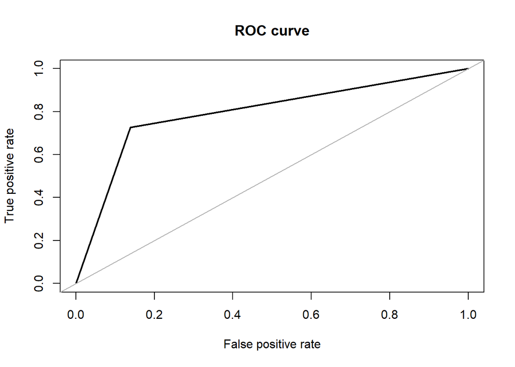

```
## Area under the curve (AUC): 0.794
```

```r
shopping_logit_pred<-predict(shopping_logit,type='response', newdata = shopping_test)
shopping_logit_pred[shopping_logit_pred>0.5]<-'TRUE'
shopping_logit_pred[shopping_logit_pred<0.5]<-'FALSE'
shopping_logit_pred<-as.factor(shopping_logit_pred)

roc.curve(response=shopping_test$Revenue, predicted=shopping_logit_pred)
```

Our ROC curve returns an AUC of 0.794, which is a pretty good model already.

Next is the LDA ROC curve

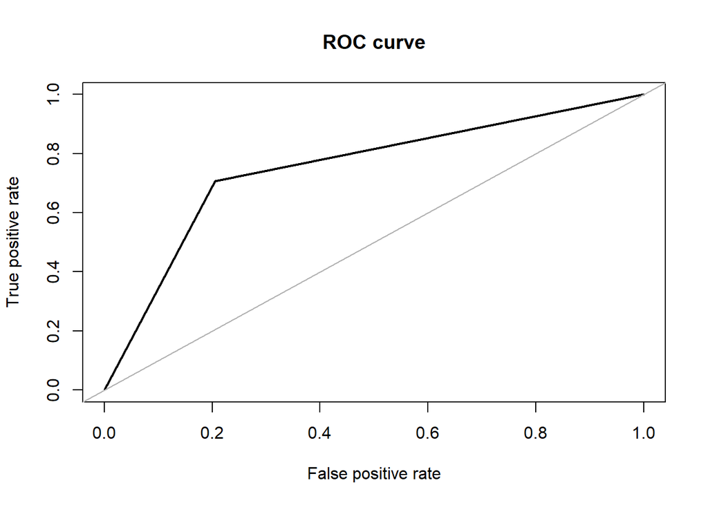

```
## Area under the curve (AUC): 0.751
```

```r
shopping_lda_pred<-predict(shopping_lda, newdata = shopping_test)$class

roc.curve(response=shopping_test$Revenue, predicted=shopping_lda_pred)
```

The linear discriminant analysis model actually performed worse on validation data than the logistic model did.

Last, the QDA ROC curve

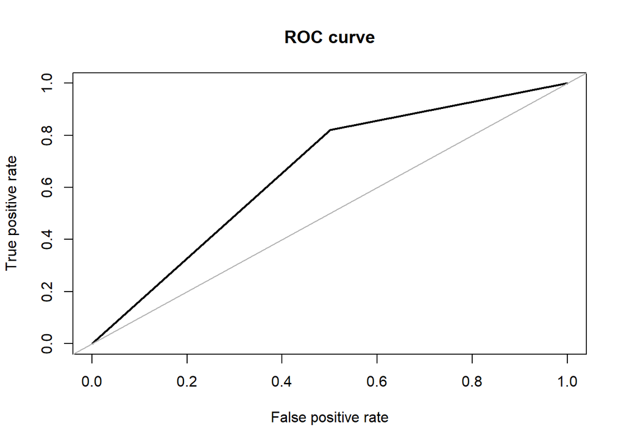

```
## Area under the curve (AUC): 0.660
```

```r
shopping_qda_pred<-predict(shopping_qda, newdata = shopping_test)$class

roc.curve(response=shopping_test$Revenue, predicted=shopping_qda_pred)
```

The QDA model actually performed the worst on validation data, which could clue us into the idea that making a model more complicated doesn’t neccessarily make it better.